# Coastal vs. Landlocked Happiness Analysis for U.S. States

For this section, I tried to look for the relationship between geographic location (coastal or landlocked) and state-level happiness scores in the United States, like I did for analyzing the countries.

```r
# Load libraries
library(tidyverse)
library(sf)
library(spdep)
library(viridis)
library(readxl)
library(rnaturalearth)
library(rnaturalearthdata)
library(corrplot)
```

```r
# Load spatial and happiness datasets
us_states <- ne_states(country = "United States of America", returnclass = "sf")
happiness_state <- read_csv("../data/happiest-states-2024.csv", show_col_types = FALSE)
```

```r
# Merge spatial and happiness data
merged_sf <- left_join(us_states, happiness_state, by = c("name" = "state"))
merged_sf <- merged_sf[!is.na(merged_sf$`HappiestStatesTotalHappinessScore`), ] # Remove rows with missing happiness scores
```

```r
merged_sf <- st_transform(merged_sf, crs = 3857)
```

```r
# Load coastline data
coastline <- ne_download(scale = "medium", type = "coastline", category = "physical", returnclass = "sf")
# Combine coastlines into a single geometry
coastline_union <- st_union(coastline)
```

```r
# Ensure merged_sf and coastline_union have the same CRS
if (st_crs(merged_sf) != st_crs(coastline_union)) {
  coastline_union <- st_transform(coastline_union, st_crs(merged_sf))
}
```

```r
# Categorize countries as coastal or landlocked
merged_sf$coastal <- ifelse(
  lengths(st_is_within_distance(merged_sf$geometry, coastline_union, dist = 5 * 1000)) > 0,
  "Coastal",
  "Landlocked"
)
```

```r
# Compute summary statistics
coastal_stats <- merged_sf %>%
  group_by(coastal) %>%
  summarize(avg_happiness = mean(HappiestStatesTotalHappinessScore, na.rm = TRUE))

print(coastal_stats)
```

```
Simple feature collection with 2 features and 2 fields
Geometry type: MULTIPOLYGON
Dimension:     XY
Bounding box:  xmin: -19942160 ymin: 2143886 xmax: 20013120 ymax: 11544810
Projected CRS: WGS 84 / Pseudo-Mercator
# A tibble: 2 × 3
  coastal    avg_happiness                                              geometry
  <chr>              <dbl>                                    <MULTIPOLYGON [m]>
1 Coastal             53.0 (((-18701660 2877762, -18701180 2877177, -18701125 2…
2 Landlocked          50.1 (((-12046452 3732332, -12046452 3731412, -12046452 3…
```

States are classified as Coastal or Landlocked based on their proximity to coastlines (within 5 km). Summary statistics reveal that coastal states have slightly higher average happiness scores (53.0) compared to landlocked states (50.1). This difference suggests that geographic features like access to coastal resources or tourism might influence well-being.

### Exploratory Visualizations

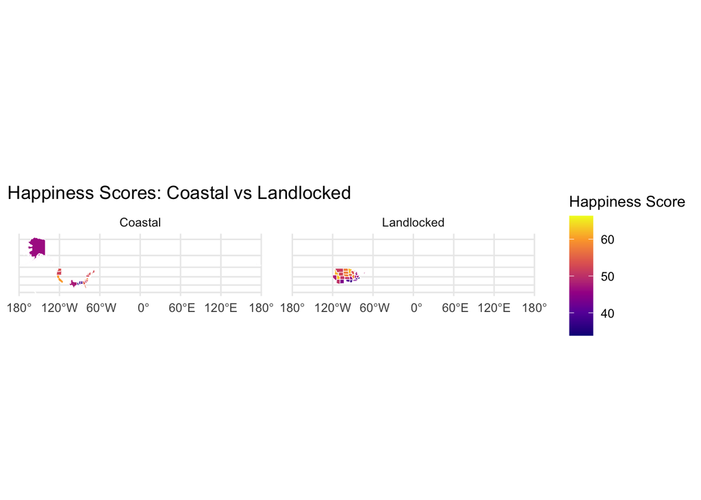

```r
# Visualize happiness scores for coastal vs. landlocked
ggplot(merged_sf) +
  geom_sf(aes(fill = HappiestStatesTotalHappinessScore), color = "white") +
  facet_wrap(~coastal) +
  scale_fill_viridis_c(option = "C") +
  theme_minimal() +
  labs(title = "Happiness Scores: Coastal vs Landlocked", fill = "Happiness Score")
```

As we found in the summary statistics, this map shows the happiness scores for coastal and landlocked states. Coastal regions generally show higher scores, particularly in states along the East and West Coasts, possibly due to economic opportunities, cultural amenities, or environmental benefits.

### Spatial Autocorrelation Analysis

```r
# Subset coastal and landlocked countries
coastal_countries <- merged_sf[merged_sf$coastal == "Coastal", ]
landlocked_countries <- merged_sf[merged_sf$coastal == "Landlocked", ]

# Create spatial weights for coastal countries
coastal_coords <- st_coordinates(st_centroid(coastal_countries))
coastal_knn <- spdep::knearneigh(coastal_coords, k = 5)
coastal_listw <- spdep::nb2listw(spdep::knn2nb(coastal_knn), style = "W")

# Moran's I for coastal countries
coastal_moran <- spdep::moran.test(coastal_countries$HappiestStatesTotalHappinessScore, coastal_listw)
print(coastal_moran)
```

```
    Moran I test under randomisation

data:  coastal_countries$HappiestStatesTotalHappinessScore
weights: coastal_listw

Moran I statistic standard deviate = 2.6512, p-value = 0.00401
alternative hypothesis: greater
sample estimates:
Moran I statistic       Expectation          Variance
      0.221287126      -0.043478261       0.009972959
```

```r
# Create spatial weights for landlocked countries
landlocked_coords <- st_coordinates(st_centroid(landlocked_countries))
landlocked_knn <- spdep::knearneigh(landlocked_coords, k = 5)
landlocked_listw <- spdep::nb2listw(spdep::knn2nb(landlocked_knn), style = "W")

# Moran's I for landlocked countries
landlocked_moran <- spdep::moran.test(landlocked_countries$HappiestStatesTotalHappinessScore, landlocked_listw)
print(landlocked_moran)
```

```
    Moran I test under randomisation

data:  landlocked_countries$HappiestStatesTotalHappinessScore
weights: landlocked_listw

Moran I statistic standard deviate = 3.6343, p-value = 0.0001393
alternative hypothesis: greater
sample estimates:
Moran I statistic       Expectation          Variance
       0.33191724       -0.04000000        0.01047228
```

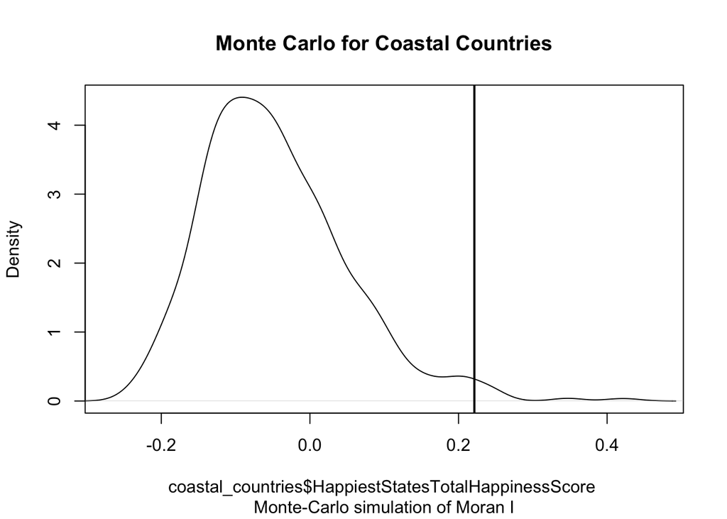

```r
# Monte Carlo simulation for coastal countries
coastal_mc <- spdep::moran.mc(coastal_countries$HappiestStatesTotalHappinessScore, coastal_listw, nsim = 999)
plot(coastal_mc, main = "Monte Carlo for Coastal Countries")
```

```r
print(coastal_mc)
```

```
    Monte-Carlo simulation of Moran I

data:  coastal_countries$HappiestStatesTotalHappinessScore
weights: coastal_listw
number of simulations + 1: 1000

statistic = 0.22129, observed rank = 986, p-value = 0.014
alternative hypothesis: greater
```

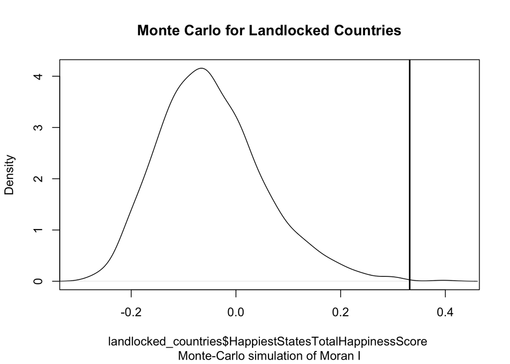

```r
# Monte Carlo simulation for landlocked countries
landlocked_mc <- spdep::moran.mc(landlocked_countries$HappiestStatesTotalHappinessScore, landlocked_listw, nsim = 999)
plot(landlocked_mc, main = "Monte Carlo for Landlocked Countries")
```

```r
print(landlocked_mc)
```

```
    Monte-Carlo simulation of Moran I

data:  landlocked_countries$HappiestStatesTotalHappinessScore
weights: landlocked_listw
number of simulations + 1: 1000

statistic = 0.33192, observed rank = 999, p-value = 0.001
alternative hypothesis: greater
```

Moran’s I analysis showed strong spatial autocorrelation for both groups, with landlocked countries exhibiting a higher Moran’s I value (0.332) compared to coastal countries (0.221). This indicates tighter clustering of happiness scores among landlocked countries, where neighboring regions often share similar happiness levels, unlike the result we found from the country-level data. Maybe as we supposed in the country-level data analysis, as there were too many countries that were classified as ‘coastal’, this might have led to a misinterpretation, or there are more other features contributing to the happiness scores for landlocked states in the United States. The Monte Carlo simulations confirmed the significance of these findings (p-value < 0.05), suggesting geography influences happiness distribution.

```r
# Convert political_freedom_category to numeric
merged_sf$coastal_numeric <- as.numeric(as.factor(merged_sf$coastal))

# Compute Moran's I for Political Freedom
coastal_countries_nb <- spdep::poly2nb(merged_sf, queen = TRUE)

# Allow empty neighbor sets
coastal_countries_listw <- spdep::nb2listw(coastal_countries_nb, style = "W", zero.policy = TRUE)

# Compute Moran's I for the numeric version of political freedom
coastal_countries_moran <- spdep::moran.test(merged_sf$coastal_numeric, coastal_countries_listw, zero.policy = TRUE)

# Print the Moran's I result
print(coastal_countries_moran)
```

```
    Moran I test under randomisation

data:  merged_sf$coastal_numeric
weights: coastal_countries_listw
n reduced by no-neighbour observations

Moran I statistic standard deviate = 5.6474, p-value = 8.143e-09
alternative hypothesis: greater
sample estimates:
Moran I statistic       Expectation          Variance
       0.54422772       -0.02127660        0.01002697
```

Also, the positive and significant Moran’s I value, 0.544, indicates spatial clustering of the coastal classification. This means that geographically proximate states tend to share similar geographic features (e.g., clusters of coastal states along the Atlantic or Pacific). This clustering underscores the geographic organization of U.S. states, with neighboring regions often sharing similar proximity to coastlines and related characteristics.

### Insights and Observations

Geographic Influence on Happiness:

Coastal states tend to have higher happiness scores than landlocked states. This could be attributed to factors like economic diversity, access to recreational areas, or enhanced cultural and social opportunities. Regional Clustering:

Coastal states are spatially clustered, with higher happiness scores concentrated along the U.S. coasts. This suggests that geographic proximity plays a role in shaping shared economic, environmental, or social conditions. Policy Implications:

Policymakers in landlocked states could consider initiatives to improve happiness by replicating factors associated with coastal success, such as enhancing access to cultural or recreational activities.